# R Lab2. Anotaciones en R y búsquedas en Pubmed

Bioinformática. Ingeniería Biomédica

# Anotaciones con Bioconductor

## Instalar Bioconductor

[Bioconductor](http://www.bioconductor.org) contiene una colección de paquetes de R dedicados al análisis y comprensión de datos genómicos. Estas librerías contienen funcionalidades para una gran variedad de tareas relacionadas con la bioinformática.

Antes de instalar paquetes específicos de Bioconductor debemos instalar el paquete `BiocManager` desde el repositorio CRAN,

```r
install.packages("BiocManager")
```

Para instalar paquetes específicos de Bioconductor utilizamos la función `install()` de `BiocManager`. Por ejemplo, para instalar el paquete `AnnotationDbi`:

```r
BiocManager::install("AnnotationDbi",force=TRUE)
```

## Conversión de identificadores de gen

Una tarea habitual que tendremos que hacer cuando analizamos datos bioinformáticos es convertir distintos tipos de identificadores de gen, que dependerán de la base de datos donde estén anotados y que no siempre tienen una correspondencia 1:1. Como ejemplo vamos a convertir identificadores de gen en Entrez (*Entrez gene ID*) en símbolos de gen (*gene symbol* según el *Human Genome Organisation* (HUGO) *Gene Nomenclature Committee*) y viceversa.

Necesitamos:

- Cargar el paquete `AnnotationDbi` de Bioconductor en nuestra sesión.
- Cargar el paquete de anotación referente al organismo con el que vamos a trabajar (*OrgDb*). En este caso trabajamos con ser humano, por tanto `org.Hs.eg.db`, que cargara en nuestra sesión de R la anotación en Entrez de ser humano.
- Un listado de genes, sus identificadores *Entrez IDs*, que queremos convertir a *gene symbol*. Crea un objeto de tipo `vector` con estos identificadores: 1, 10, 100, 1000 y 37690.

**Solución:**

Primero comprobamos si tenemos instaladas las librerias y si no es así, las instalamos.

```r
if(!("org.Hs.eg.db" %in% installed.packages()))
  BiocManager::install("org.Hs.eg.db")
```

Cargamos las librerías y el vector de identificadores Entrez,

```r
library("AnnotationDbi")
library("org.Hs.eg.db")

# El listado de Entrez gene IDs de interés en un vector
myEIDs <- c("1", "10", "100", "1000", "37690")
```

En un paquete de tipo organismo (*OrgDb*) hay varios tipos de anotaciones disponibles que podéis consultar con la instrucción,

```r
ls("package:org.Hs.eg.db")
```

```
##  [1] "org.Hs.eg"                "org.Hs.eg.db"
##  [3] "org.Hs.eg_dbconn"         "org.Hs.eg_dbfile"
##  [5] "org.Hs.eg_dbInfo"         "org.Hs.eg_dbschema"
##  [7] "org.Hs.egACCNUM"          "org.Hs.egACCNUM2EG"
##  [9] "org.Hs.egALIAS2EG"        "org.Hs.egCHR"
## [11] "org.Hs.egCHRLENGTHS"      "org.Hs.egCHRLOC"
## [13] "org.Hs.egCHRLOCEND"       "org.Hs.egENSEMBL"
## [15] "org.Hs.egENSEMBL2EG"      "org.Hs.egENSEMBLPROT"
## [17] "org.Hs.egENSEMBLPROT2EG"  "org.Hs.egENSEMBLTRANS"
## [19] "org.Hs.egENSEMBLTRANS2EG" "org.Hs.egENZYME"
## [21] "org.Hs.egENZYME2EG"       "org.Hs.egGENENAME"
## [23] "org.Hs.egGENETYPE"        "org.Hs.egGO"
## [25] "org.Hs.egGO2ALLEGS"       "org.Hs.egGO2EG"
## [27] "org.Hs.egMAP"             "org.Hs.egMAP2EG"
## [29] "org.Hs.egMAPCOUNTS"       "org.Hs.egOMIM"
## [31] "org.Hs.egOMIM2EG"         "org.Hs.egORGANISM"
## [33] "org.Hs.egPATH"            "org.Hs.egPATH2EG"
## [35] "org.Hs.egPFAM"            "org.Hs.egPMID"
## [37] "org.Hs.egPMID2EG"         "org.Hs.egPROSITE"
## [39] "org.Hs.egREFSEQ"          "org.Hs.egREFSEQ2EG"
## [41] "org.Hs.egSYMBOL"          "org.Hs.egSYMBOL2EG"
## [43] "org.Hs.egUCSCKG"          "org.Hs.egUNIPROT"
```

En este paquete, `org.Hs.eg.db`, la anotación central es la de Entrez (`eg`). Así, por ejemplo, podríamos convertir *Entrez IDs* a *RefSeq* (`org.Hs.egREFSEQ`) o *Ensembl IDs* (`org.Hs.egENSEMBL`) y viceversa (`org.Hs.egREFSEQ2EG` y `org.Hs.egENSEMBL2EG`, repectivamente). En este último caso, se añade el sufijo `...2EG`.

Queremos obtener la correspondecia *Entrez IDs* a *gene symbol*, ¿cuál sería la anotación a utilizar? ¿Y para transformar *gene symbol* en *Entrez IDs*?

**Solución:**

- De *Entrez IDs* a *gene symbol*: `org.Hs.egSYMBOL`
- De *gene symbol* en *Entrez IDs*: `org.Hs.egSYMBOL2EG`

La función `AnnotationDbi::mget()` permite hacer las conversiones entre identificadores y requiere de dos argumentos: el vector con los identificadores a traducir y una anotación. Además, podemos utilizar el argumento `ifnotfound` para asignar `NA` a aquellos identificadores que no se encuentran. Haz la conversión de *Entrez ID* a *gene symbols* utilizando `AnnotationDbi::mget()`.

**Solución:**

Para traducir los identificadores a *gene symbols* utilizamos la función `mget()` y la anotación `org.Hs.egSYMBOL` con el siguiente código:

```r
(mySymbols <- AnnotationDbi::mget(myEIDs, org.Hs.egSYMBOL, ifnotfound=NA))
```

```
## $`1`
## [1] "A1BG"
##
## $`10`
## [1] "NAT2"
##
## $`100`
## [1] "ADA"
##
## $`1000`
## [1] "CDH2"
##
## $`37690`
## [1] NA
```

La función `mget()` devuelve una lista cuyos elementos se nombran con el correspondiente identificador de partida, *Entrez ID* en este caso (`myEIDs`). Convierte la lista en un `vector`.

**Solución:**

Podemos transformar la lista en un `vector` con la función `unlist()`:

```r
(mySymbols <- unlist(mySymbols))
```

```
##      1     10    100   1000  37690
## "A1BG" "NAT2"  "ADA" "CDH2"     NA
```

Ahora vamos a volver a los *Entrez IDs*. El primer paso será seleccionar los identificadores informativos, es decir los distintos de `NA`, y después volver a utilizar la función `mget()`, con la anotación que corresponda.

**Solución:**

Ahora la anotación debe ser `org.Hs.egSYMBOL2EG`.

```r
# eliminamos los NA: función is.na()
y <- mySymbols[!is.na(mySymbols)]
(myEIDs <- unlist(mget(y, org.Hs.egSYMBOL2EG, ifnotfound=NA)))
```

```
##   A1BG   NAT2    ADA   CDH2
##    "1"   "10"  "100" "1000"
```

Notad que el nombre de los elementos del vector es el *gene symbol* correspondiente.

## Anotaciones en GO

Gene Ontology ([GO](http://geneontology.org/) proporciona información sobre las características de genes y productos génicos a través de su anotación. Los términos GO recogen lo que se conoce de los genes en términos de su función, fisiología y localización celular, proporcionando una buena descripción a nivel biológico. Veamos como mapear un conjunto de genes en los términos GO en los que están anotados. Necesitaremos:

- tener instalado y cargado el paquete `GO.db`.
- cargar el paquete de anotación del organismo que corresponda. Para ser humano `org.Hs.eg.db`.

**Solución:**

```r
# comprobamos si lo tenemos instalado antes de hacer
if(!("GO.db" %in% installed.packages()))
  BiocManager::install("GO.db")
# cargamos el paquete
library("GO.db")
library("org.Hs.eg.db")
```

Queremos obtener la correspondecia Entrez IDs a la(s) categoría(s) GO en las que están anotados, ¿cuál sería la anotación a utilizar? ¿Y para transformar GO en Entrez IDs?

**Solución:**

De Entrez IDs a GO: `org.Hs.egGO` De GO en Entrez IDs: `org.Hs.egGO2EG`

Recordad que podeis consultar las anotaciones disponibles con la instrucción,

```r
ls("package:org.Hs.eg.db")
```

### De gen a GO

Partimos de una lista de identificadores *Entrez IDs* de genes que queremos anotar en GO, por ejemplo el gen 1, 10 y 100. **Nota:** Es conveniente que el punto de partida sea ese indentificador Entrez, si no es así, siempre podéis convertir el listado como hemos hecho anteriormente. Encontrar la anotación GO del segundo gen.

**Solución:**

Vector con los identificadores *Entrez IDs*,

```r
myEIDs <- c("1", "10", "100")
```

Accedemos a las anotaciones como accedemos a las listas,

```r
(myGO <- org.Hs.egGO[[myEIDs[2]]])
```

```
## $`GO:0006805`
## $`GO:0006805`$GOID
## [1] "GO:0006805"
##
## $`GO:0006805`$Evidence
## [1] "TAS"
##
## $`GO:0006805`$Ontology
## [1] "BP"
##
##
## $`GO:0005829`
## $`GO:0005829`$GOID
## [1] "GO:0005829"
##
## $`GO:0005829`$Evidence
## [1] "TAS"
##
## $`GO:0005829`$Ontology
## [1] "CC"
##
##
## $`GO:0004060`
## $`GO:0004060`$GOID
## [1] "GO:0004060"
##
## $`GO:0004060`$Evidence
## [1] "IBA"
##
## $`GO:0004060`$Ontology
## [1] "MF"
##
##
## $`GO:0004060`
## $`GO:0004060`$GOID
## [1] "GO:0004060"
##
## $`GO:0004060`$Evidence
## [1] "TAS"
##
```

[output cut: 9 more lines]

```
## [1] "IPI"
##
## $`GO:0005515`$Ontology
## [1] "MF"
##
##
## $`GO:0046990`
## $`GO:0046990`$GOID
## [1] "GO:0046990"
##
## $`GO:0046990`$Evidence
## [1] "IDA"
##
## $`GO:0046990`$Ontology
## [1] "MF"
```

El resultado de la anotación es una lista en la que cada elemento, nombrado como la categoría GO a la que pertenece el gen, es otra lista que contiene tres elementos:

- El identificador del término GO (`GOID`).
- Evidencia de la anotación (Evidence), que incluye un código que indica como está soportada la anotación. En general podrá ser de 6 tipos, de mayor a menor fuerza: experimental, filogenética, computacional, publicada en alguna referencia, identificada por autores de otras anotaciones o automáticas. Dentro de cada tipo hay subtipos cuyos códigos se pueden consultar en (http://geneontology.org/docs/guide-go-evidence-codes/).
- La ontología a la que pertenece, que puede ser: proceso biológico (BP: Biological Process), función molecular (MF: Molecular Function) or componente celular (CC: Cellular Components).

Podemos utilizar la función `mget()` para obtener la anotación de todos los genes,

```r
myGO_All <- mget(myEIDs, org.Hs.egGO)
```

Contruye un vector con los identificadores de todas las categorías GO en las que están anotados esos genes. Nota: podeis utilizar la función `names()` para recuperar los nombres de elementos de una lista que le pasais como argumento y `lapply()` para repetir `names()` en cada elemento de la lista.

**Solución:**

Los nombres de cada elemento de la lista se corresponden con los identificadores GO. Así, para el primer gen,

```r
names(myGO_All[[1]])
```

```
##  [1] "GO:0002764" "GO:0008150" "GO:0005576" "GO:0005576" "GO:0005576"
##  [6] "GO:0005615" "GO:0005886" "GO:0031093" "GO:0034774" "GO:0062023"
## [11] "GO:0070062" "GO:0072562" "GO:1904813" "GO:0003674"
```

Podríamos utilizar la función `lapply()` para obtener la información de todos los genes,

```r
lapply(myGO_All,names)
```

```
## $`1`
##  [1] "GO:0002764" "GO:0008150" "GO:0005576" "GO:0005576" "GO:0005576"
##  [6] "GO:0005615" "GO:0005886" "GO:0031093" "GO:0034774" "GO:0062023"
## [11] "GO:0070062" "GO:0072562" "GO:1904813" "GO:0003674"
##
## $`10`
## [1] "GO:0006805" "GO:0005829" "GO:0004060" "GO:0004060" "GO:0005515"
## [6] "GO:0046990"
##
## $`100`
##  [1] "GO:0000255" "GO:0001666" "GO:0001829" "GO:0001889" "GO:0001890"
##  [6] "GO:0002314" "GO:0002467" "GO:0002636" "GO:0002686" "GO:0002901"
## [11] "GO:0002906" "GO:0006154" "GO:0006154" "GO:0006154" "GO:0006157"
## [16] "GO:0006196" "GO:0006805" "GO:0006939" "GO:0007155" "GO:0010460"
## [21] "GO:0014074" "GO:0019722" "GO:0030890" "GO:0032261" "GO:0032263"
## [26] "GO:0033077" "GO:0033089" "GO:0033632" "GO:0042100" "GO:0042110"
## [31] "GO:0042110" "GO:0043084" "GO:0043101" "GO:0043103" "GO:0043605"
## [36] "GO:0044209" "GO:0045987" "GO:0046059" "GO:0046061" "GO:0046085"
## [41] "GO:0046103" "GO:0046103" "GO:0046103" "GO:0046111" "GO:0046632"
## [46] "GO:0046638" "GO:0048286" "GO:0048541" "GO:0048566" "GO:0050728"
## [51] "GO:0050850" "GO:0050852" "GO:0050862" "GO:0050900" "GO:0060169"
## [56] "GO:0060169" "GO:0060407" "GO:0070242" "GO:0070244" "GO:0070254"
## [61] "GO:0070256" "GO:0005764" "GO:0005829" "GO:0005829" "GO:0005829"
## [66] "GO:0005886" "GO:0009897" "GO:0009897" "GO:0009986" "GO:0016020"
## [71] "GO:0060205" "GO:0070161" "GO:0004000" "GO:0004000" "GO:0004000"
## [76] "GO:0004000" "GO:0005515" "GO:0008270" "GO:0008270" "GO:0019239"
## [81] "GO:0019239" "GO:0046936"
```

Si queremos construir un vector podemos utilizar la función `unlist()`,

```r
unlist(lapply(myGO_All,names))
```

```
##           11           12           13           14           15           16
## "GO:0002764" "GO:0008150" "GO:0005576" "GO:0005576" "GO:0005576" "GO:0005615"
##           17           18           19          110          111          112
## "GO:0005886" "GO:0031093" "GO:0034774" "GO:0062023" "GO:0070062" "GO:0072562"
##          113          114          101          102          103          104
## "GO:1904813" "GO:0003674" "GO:0006805" "GO:0005829" "GO:0004060" "GO:0004060"
##          105          106         1001         1002         1003         1004
## "GO:0005515" "GO:0046990" "GO:0000255" "GO:0001666" "GO:0001829" "GO:0001889"
##         1005         1006         1007         1008         1009        10010
## "GO:0001890" "GO:0002314" "GO:0002467" "GO:0002636" "GO:0002686" "GO:0002901"
##        10011        10012        10013        10014        10015        10016
## "GO:0002906" "GO:0006154" "GO:0006154" "GO:0006154" "GO:0006157" "GO:0006196"
##        10017        10018        10019        10020        10021        10022
## "GO:0006805" "GO:0006939" "GO:0007155" "GO:0010460" "GO:0014074" "GO:0019722"
##        10023        10024        10025        10026        10027        10028
## "GO:0030890" "GO:0032261" "GO:0032263" "GO:0033077" "GO:0033089" "GO:0033632"
##        10029        10030        10031        10032        10033        10034
## "GO:0042100" "GO:0042110" "GO:0042110" "GO:0043084" "GO:0043101" "GO:0043103"
##        10035        10036        10037        10038        10039        10040
## "GO:0043605" "GO:0044209" "GO:0045987" "GO:0046059" "GO:0046061" "GO:0046085"
##        10041        10042        10043        10044        10045        10046
## "GO:0046103" "GO:0046103" "GO:0046103" "GO:0046111" "GO:0046632" "GO:0046638"
##        10047        10048        10049        10050        10051        10052
## "GO:0048286" "GO:0048541" "GO:0048566" "GO:0050728" "GO:0050850" "GO:0050852"
##        10053        10054        10055        10056        10057        10058
## "GO:0050862" "GO:0050900" "GO:0060169" "GO:0060169" "GO:0060407" "GO:0070242"
##        10059        10060        10061        10062        10063        10064
## "GO:0070244" "GO:0070254" "GO:0070256" "GO:0005764" "GO:0005829" "GO:0005829"
##        10065        10066        10067        10068        10069        10070
## "GO:0005829" "GO:0005886" "GO:0009897" "GO:0009897" "GO:0009986" "GO:0016020"
##        10071        10072        10073        10074        10075        10076
## "GO:0060205" "GO:0070161" "GO:0004000" "GO:0004000" "GO:0004000" "GO:0004000"
##        10077        10078        10079        10080        10081        10082
## "GO:0005515" "GO:0008270" "GO:0008270" "GO:0019239" "GO:0019239" "GO:0046936"
```

y para eliminar los repetidos, `unique()`,

```r
unique(unlist(lapply(myGO_All,names)))
```

```
##  [1] "GO:0002764" "GO:0008150" "GO:0005576" "GO:0005615" "GO:0005886"
##  [6] "GO:0031093" "GO:0034774" "GO:0062023" "GO:0070062" "GO:0072562"
## [11] "GO:1904813" "GO:0003674" "GO:0006805" "GO:0005829" "GO:0004060"
## [16] "GO:0005515" "GO:0046990" "GO:0000255" "GO:0001666" "GO:0001829"
## [21] "GO:0001889" "GO:0001890" "GO:0002314" "GO:0002467" "GO:0002636"
## [26] "GO:0002686" "GO:0002901" "GO:0002906" "GO:0006154" "GO:0006157"
## [31] "GO:0006196" "GO:0006939" "GO:0007155" "GO:0010460" "GO:0014074"
## [36] "GO:0019722" "GO:0030890" "GO:0032261" "GO:0032263" "GO:0033077"
## [41] "GO:0033089" "GO:0033632" "GO:0042100" "GO:0042110" "GO:0043084"
## [46] "GO:0043101" "GO:0043103" "GO:0043605" "GO:0044209" "GO:0045987"
## [51] "GO:0046059" "GO:0046061" "GO:0046085" "GO:0046103" "GO:0046111"
## [56] "GO:0046632" "GO:0046638" "GO:0048286" "GO:0048541" "GO:0048566"
## [61] "GO:0050728" "GO:0050850" "GO:0050852" "GO:0050862" "GO:0050900"
## [66] "GO:0060169" "GO:0060407" "GO:0070242" "GO:0070244" "GO:0070254"
## [71] "GO:0070256" "GO:0005764" "GO:0009897" "GO:0009986" "GO:0016020"
## [76] "GO:0060205" "GO:0070161" "GO:0004000" "GO:0008270" "GO:0019239"
## [81] "GO:0046936"
```

### De GO a gen

A partir de un identificador GO también podemos obtener los genes anotados en esa categoría. Para obtener los *Entrez ID* de los genes anotados en las categorías “GO:0008150” y “GO:0001909”, utiliza `mget()` con la anotación que corresponda.

**Solución:**

Con la función `mget()` podemos obtener los *Entrez ID* de varias categorías GO. Por ejemplo,

```r
GOterm <- c("GO:0008150", "GO:0001909")
GOgenes_All <- mget(GOterm, org.Hs.egGO2EG)
```

Se pueden consultar detalles de la ontología GO en la referencia (Ontology 2000).

# PubMed en R

En esta segunda parte del laboratorio, vamos a trabajar con información sobre las publicaciones en PubMed utilizando R.

[PubMed](https://pubmed.ncbi.nlm.nih.gov/) es una de las bases de datos del *National Center for Biotechnology Information* (NCBI), de acceso libre y especializada en ciencias de la salud, con más de 19 millones de referencias bibliográficas a la que se puede acceder a través de Entrez (*Global Query Cross-Database Search System*).

PubMed contiene las referencias de MEDLINE. MEDLINE es una base de datos de citas y abstracts de acceso online y gratuito, de carácter médico.

Utilizamos el paquete [`RISmed`](https://cran.r-project.org/web/packages/RISmed/index.html) disponible en el CRAN de R para llevar a cabo las consultas a las bases de datos. Además utilizaremos el paquete [`rentrez`](https://cran.r-project.org/web/packages/rentrez/index.html) para obtener información acerca del número de citas de estos artículos.

Vamos a ver un ejemplo que se centra en la búsqueda artículos relacionados con `BRCA1 para cáncer de mama en humanos durante el año 2024`.

## Instalar y cargar las librerías

Instala y carga las librerías que vamos a utilizar, todas ellas disponibles en CRAN: `RISmed`, `dplyr`, `rentrez`,`ggplot2`, `PubMedWordcloud` y `wordcloud2`.

**Solución:**

Antes de empezar a trabajar con las librerías debemos instalarlas y cargarlas. Como todas ellas están disponibles en CRAN para instalarlas usamos la instrucción `install.packages()`. Previamente, utilizamos una instrucción `if` para comprobar si están instaladas.

```r
# RISmed
if(!("RISmed" %in% installed.packages()))
  install.packages("RISmed")
library("RISmed")

# dplyr
if(!("dplyr" %in% installed.packages()))
  install.packages("dplyr")
library("dplyr")

# rentrez
if(!("rentrez" %in% installed.packages()))
  install.packages("rentrez")
library("rentrez")

# ggplot2
if(!("ggplot2" %in% installed.packages()))
  install.packages("ggplot2")
library("ggplot2")

# para los graficos de tipo nube de puntos: PubMedWordcloud y wordcloud2
if(!("PubMedWordcloud" %in% installed.packages()))
  install.packages("PubMedWordcloud")
if(!("wordcloud2" %in% installed.packages()))
  install.packages("wordcloud2")
library("PubMedWordcloud")
library("wordcloud2")
```

## Búsqueda en PubMed

El primer paso será establecer los términos de búsqueda. Crea un vector de longitud 1 y de tipo `character` en el que almacenes el texto de la consulta. Queremos buscar publicaciones que contengan en su título ‘BRCA1’ y ‘Breast Cancer’, publicadas en ‘2024’. El formato del *string* es el mismo que utilizaríamos para hacer la consulta directamente en PubMed.

*Nota:* En el enlace https://www.nlm.nih.gov/bsd/licensee/data_elements_doc.html?utm_source=chatgpt.com tenéis disponible la descripción de los principales campos que podéis utilizar para construir el *string* de búsqueda en PubMed.

**Solución:**

```r
search_topic <- '(BRCA1 [TI] AND Breast Cancer [TI] AND Humans) AND "2024" [EDAT]'
```

Utilizamos el operador AND para construir nuestro *string* de búsqueda y [TI] para indicar que esas palabras deben aparacer en el título. [EDAT] hace referencia a la fecha de publicación. Por tanto, vamos a buscar publicaciones que contengan en su título ‘BRCA1’ y ‘Breast Cancer,’ publicadas en ‘2024’.

He añadido ‘Humans’ en cualquier campo [All Fields] para restringir la búsqueda a ‘humano’.

Para extraer la información utilizamos las funciones `RISmed::EUtilsSummary()` y `RISmed::EUtilsGet()`. Con la primera obtenemos información resumen sobre la búsqueda que se va a llevar a cabo, y con `RISmed::EUtilsGet()` obtenemos los resultados.

- La función `RISmed::EUtilsSummary()` tiene como primer argumento el *string* de búsqueda creado en el paso anterior. Otros argumentos a utilizar son: `type="esearch"` y `db="pubmed"`, que limitan la búsqueda a Pubmed.
- La función `RISmed::EUtilsGet()` requiere como primer argumento el objeto creado con la función `RISmed::EUtilsSummary()`. Otros argumentos a utilizar son: `type = "efetch"` y `db = "pubmed"`.

Crea un objeto con los resultados de la búsqueda. ¿De qué clase es el objeto que habéis creado? ¿Cuántas publicaciones cumplen los criterios de búsqueda?

**Solución:**

```r
search_query <- EUtilsSummary(search_topic,type="esearch", db="pubmed")
(records <- EUtilsGet(search_query,type = "efetch", db = "pubmed"))
```

```
## PubMed query:  "BRCA1"[Title] AND "breast cancer"[Title] AND ("human s"[All Fields] OR "humans"[MeSH Terms] OR "humans"[All Fields] OR "human"[All Fields]) AND 2024/01/01:2024/12/31[Date - Entry]
##
## Records:  76
```

```r
class(records)
```

```
## [1] "Medline"
## attr(,"package")
## [1] "RISmed"
```

## Conjunto de datos

Vamos a hacer un análisis estadístico con los datos que hemos obtenido, pero previamente debemos construir un `data.frame` con la información que vamos a utilizar de cada publicación. Podemos recuperar la información de cada campo utilizando funciones específicas, concretamente en este caso nos va a interesar los siguientes:

1. `PMID()` que devuelve el identificador del articulo en PubMed.
2. Fecha de la publicación con dos campos: mes y día. Utilizamos las funciones `MonthEntrez()` y `DayEntrez()`, respectivamente.
3. Título, con la función `ArticleTitle()`.
4. El identificador DOI (Digital Object Identifier) del artículo (`DOI()`).
5. País (`Country()`)
6. El tipo de publicación (`PublicationType()`).

Podéis consultar todos los campos que podéis obtener en la ayuda de la clase `Medline`.

```r
help("Medline")
```

**Solución:**

Construimos el `data.frame` con la función `data.frame()`:

```r
# Base de datos con la información adicional dada por RISmed
pubmed_data <- data.frame(pmid=PMID(records),
                          monthPub = MonthEntrez(records),
                          dayPub = DayEntrez(records),
                          title = ArticleTitle(records),
                          doi = DOI(records),
                          language = Language(records),
                          country=Country(records),
                          pubType = PublicationType(records))

head(pubmed_data, n=2)
```

```
##       pmid monthPub dayPub
## 1 39730675       12     27
## 2 39724887       12     26
##                                                                                         title
## 1 PARP inhibition radiosensitizes BRCA1 wildtype and mutated breast cancer to proton therapy.
## 2            BREAST CANCER AND DIAGNOSTIC METHODS: UNDERSTANDING THE ROLE OF BRCA1 AND BRCA2.
##    doi language country         pubType
## 1 <NA>      eng    <NA> Journal Article
## 2 <NA>      eng    <NA> Journal Article
```

¿Se ha podido obtener toda la información?

**Solución:**

Podríais comprobarlo utilizando la función `is.na()` que devuelve `TRUE` donde encuentra un `NA`. Si sumo por columnas compruebo que no hemos recuperado ningún doi ni ningún país (*country*),

```r
colSums(is.na(pubmed_data))
```

```
##     pmid monthPub   dayPub    title      doi language  country  pubType
##        0        0        0        0       76        0       76        0
```

#### Añadiendo información del número de citas con `rentrez`

Vamos a añadir la información del número de citas de cada uno de los artículos que hemos obtenido en nuestra consulta utilizando el paquete `rentrez`, conocido el identificador del artículo en PubMed (‘pmid’).

Para obtener el número de citas de un artículo con identificador ‘36553480’ ejecutaríamos el siguiente código,

```r
pmid <- "36553480"
pmid_summary <- entrez_summary(db="pubmed", id=pmid)
as.numeric(extract_from_esummary(pmid_summary, "pmcrefcount"))
```

```
## [1] 41
```

Generaliza este código para obtener el número de citas de todos los artículos que cumplen nuestros criterios de búsqueda. ¿Qué significa en este caso que este campo esté vacío?

**Solución:**

```r
pmid_summary <- entrez_summary(db="pubmed", id=pubmed_data[,1])
(num.citas <- as.numeric(extract_from_esummary(pmid_summary, "pmcrefcount")))
```

```
##  [1] 57 NA NA NA 69 NA 30 NA 24 NA NA NA NA 33 NA NA NA 53 NA 39 NA 34 NA NA NA
## [26] 50 32 53  9 34 55 NA 46 NA 51 45 NA 31 86 21 NA 47 NA NA 20 34 NA NA NA NA
## [51] 52 44 NA 49 32 12 NA 20 42 26 NA 13 15 50 NA NA 33 NA 34 NA 32 77 39 66 49
## [76] 27
```

Notad que hay algún artículo para el que no tenemos esa información, que se rellena con NA. En realidad esos valores no son missing, sino que no han recibido ninguna cita, es decir que serían 0. Para sustituir los NA por 0 podríamos hacer,

```r
num.citas[is.na(num.citas)] <- 0
num.citas
```

```
##  [1] 57  0  0  0 69  0 30  0 24  0  0  0  0 33  0  0  0 53  0 39  0 34  0  0  0
## [26] 50 32 53  9 34 55  0 46  0 51 45  0 31 86 21  0 47  0  0 20 34  0  0  0  0
## [51] 52 44  0 49 32 12  0 20 42 26  0 13 15 50  0  0 33  0 34  0 32 77 39 66 49
## [76] 27
```

Añade el número de citas al `data.frame` que contiene el resto de la información.

**Solución:**

```r
pubmed_data$num.citas<-num.citas
head(pubmed_data,n=2)
```

```
##       pmid monthPub dayPub
## 1 39730675       12     27
## 2 39724887       12     26
##                                                                                         title
## 1 PARP inhibition radiosensitizes BRCA1 wildtype and mutated breast cancer to proton therapy.
## 2            BREAST CANCER AND DIAGNOSTIC METHODS: UNDERSTANDING THE ROLE OF BRCA1 AND BRCA2.
##    doi language country         pubType num.citas
## 1 <NA>      eng    <NA> Journal Article        57
## 2 <NA>      eng    <NA> Journal Article         0
```

El paquete `dplyr` no proporciona ninguna nueva funcionalidad a R per se, en el sentido que todo aquello que podemos hacer con él lo podríamos hacer con la sintaxis básica de R. Sin embargo, es especialmente útil porque proporciona una “gramática” que facilita la manipulación y operaciones con data frames. Proporciona una serie de funciones, conocidas como “verbos”, que permiten realizar operaciones comunes de manera intuitiva y legible. Estas funciones incluyen `filter()` para seleccionar filas que cumplen con condiciones específicas; `select()` para elegir columnas específicas; `mutate()` para crear nuevas variables o transformar las existentes; o `summarize()` para generar resúmenes estadísticos de las variables. Estas funciones pueden encadenarse utilizando el operador pipe (`%>%`), lo que permite construir secuencias de operaciones de manera clara y concisa.

Por ejemplo,

```r
pubmed_data <- pubmed_data %>% mutate(title=substr(title,1,20)) %>% #reducimos a 20 caracteres
  dplyr::distinct(pmid,.keep_all = TRUE) # seleccionamos los pmid distintos
pubmed_data[1,]
```

```
##       pmid monthPub dayPub                title  doi language country
## 1 39730675       12     27 PARP inhibition radi <NA>      eng    <NA>
##           pubType num.citas
## 1 Journal Article        57
```

La función `dplyr::mutate()` sirve para añadir nuevas variables y conservar algunas ya existentes en el data frame `pubmed_data`. La función `base::substr()` extrae los caracteres desde la posición `start` hasta `stop`. Con `dplyr::distinct()` seleccionamos las filas distintas de `pubmed_data` en la variable `pmid`. Usamos el argumento `.keep_all=TRUE` para mantene en el `data.frame` resultado todas las variables de `pubmed_data`.

Vamos a utilizar el paquete `DT` disponible en CRAN para mostrar la información de una forma más amigable, en forma de tabla interactiva:

```r
# para presentarlo en forma de tabla necesitamos el paquete DT
if(!("DT" %in% installed.packages()))
  install.packages("DT")
library("DT")

pubmed_data %>% DT::datatable()
```

|  | pmid | monthPub | dayPub | title | doi | language | country | pubType | num.citas |
| --- | --- | --- | --- | --- | --- | --- | --- | --- | --- |
| 1 | 39730675 | 12 | 27 | PARP inhibition radi |  | eng |  | Journal Article | 57 |
| 2 | 39724887 | 12 | 26 | BREAST CANCER AND DI |  | eng |  | Journal Article | 0 |
| 3 | 39663109 | 12 | 11 | Predicting the likel |  | eng |  | Journal Article | 0 |
| 4 | 39609372 | 11 | 28 | Secondary Risk-Reduc |  | eng |  | Journal Article | 0 |
| 5 | 39567747 | 11 | 20 | Luminal breast epith |  | eng |  | Journal Article | 69 |
| 6 | 39561108 | 11 | 19 | Anthracyclines-induc |  | eng |  | Journal Article | 0 |
| 7 | 39544591 | 11 | 15 | Real-World Clinical |  | eng |  | Journal Article | 30 |
| 8 | 39528827 | 11 | 11 | Brca1 haploinsuffici |  | eng |  | Journal Article | 0 |
| 9 | 39520738 | 11 | 9 | Olaparib monotherapy |  | eng |  | Journal Article | 24 |
| 10 | 39506289 | 11 | 7 | A Pilot Study on BRC |  | eng |  | Journal Article | 0 |

[output cut: 66 more lines]

Por último, utilizamos la función `DT::datatable()` para crear una tabla en html con el `data.frame` resultado.

## Resumen de los datos

Utilizamos el paquete `ggplot2` para construir gráficos. Este paquete permite elaborar un gráfico a partir de un proceso de acumulación de capas o “layers”. Tiene un cierto nivel de complejidad pero se obtienen resultados muy profesionales. Lo básico de este paquete lo podéis encontrar en http://www.cookbook-r.com/Graphs/.

Las capas se van combinando con el signo `+`. Las más relevantes:

- Un data frame y las variables a representar
- El tipo de objeto(s) a representar o `geom` (barra, línea, punto, etc.)
- Es posible personalizar cada detalle de un gráfico, como los colores, tipos de líneas, fuentes o alineación, entre otros, usando los componentes de la función `theme`.
- Otras funciones que permiten añadir títulos, subtítulos, líneas, flechas o textos.

Con el siguiente código generamos un **gráfico de barras** en el que representamos el **número de publicaciones por mes**,

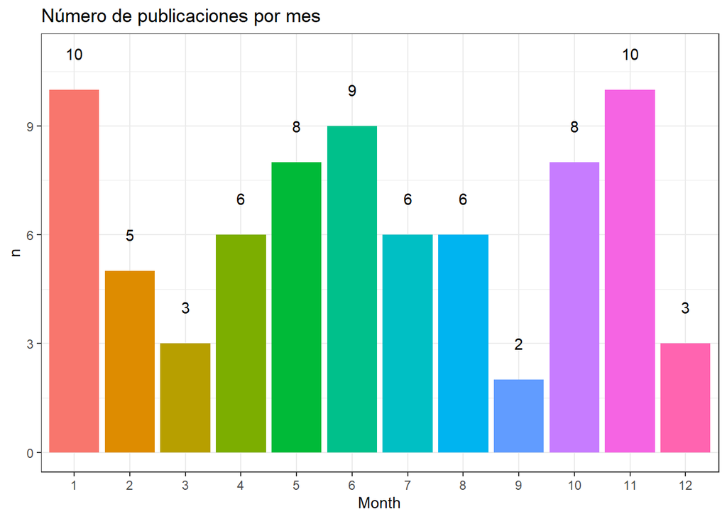

```r
pubmed_data %>% group_by(Month=factor(monthPub)) %>%
  summarise(n=n()) %>%
    ggplot(aes(x=Month,y=n,fill=Month)) +
    geom_bar(stat = "identity") +
    geom_text(aes(label=n),nudge_y = 1) +
    theme_bw() + theme(legend.position = "none") +
    ggtitle("Número de publicaciones por mes")
```

En las dos primeras líneas se utiliza funciones del paquete `dplyr` para crear un nuevo data frame a partir de `pubmed_data` que contiene el número de las publicaciones distintas cada mes.

```r
pubmed_data %>% group_by(Month=factor(monthPub)) %>%
  summarise(n=n())
```

```
## # A tibble: 12 × 2
##    Month     n
##    <fct> <int>
##  1 1        10
##  2 2         5
##  3 3         3
##  4 4         6
##  5 5         8
##  6 6         9
##  7 7         6
##  8 8         6
##  9 9         2
## 10 10        8
## 11 11       10
## 12 12        3
```

Las siguientes líneas son funciones del paquete `ggplot2` que generan el gráfico a partir de ese nuevo data frame.

- Con `ggplot()` indicamos las variables que vamos a utilizar: en el eje de las X el mes, en el eje Y el número de publicaciones y el color será distinto para cada mes.
- `geom_bar()` indica que queremos un gráfico de barras.
- Con `geom_text()` añadimos el texto encima de la barra.
- `theme_bw()` para indicar un tipo de aspecto del gráfico preconfigurado distinto del clásico, optimizado para proyector.
- Con `theme()` eliminamos la leyenda.
- Y por último, con `ggtitle()` añadimos un título.

Utiliza `coord_polar(theta = "y")` para representar en un **gráfico de sectores** en el que representamos el **número de citaciones por tipo de publicación**.

**Solución:**

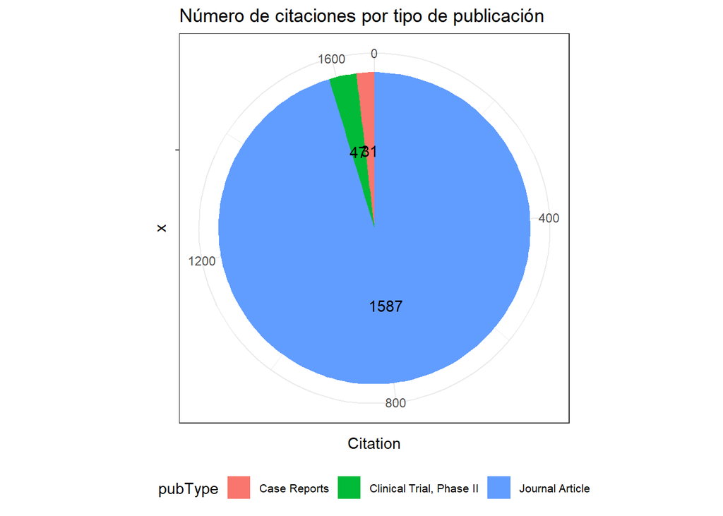

```r
pubmed_data %>% group_by(pubType) %>%
  summarise(Citation=sum(num.citas)) %>% na.omit() %>%
    ggplot(aes(x="",y=Citation,fill=pubType)) +
    geom_col() + coord_polar(theta = "y") +
    theme_bw()+
    geom_text(aes(label = Citation),
            position = position_stack(vjust = 0.5)) +
    theme(legend.position="bottom",legend.text = element_text(size=8)) +
    ggtitle("Número de citaciones por tipo de publicación")
```

### Gráficos nubes de palabras

Vamos a crear un gráfico con las palabras que aparecen en los abstracts de las publicaciones seleccionadas. El primer paso será obtener los abstracts. Utiliza la función `getAbstracts()` del paquete `PubMedWordcloud`.

**Solución:**

A la función `PubMedWordcloud::getAbstracts()` hay que pasarle como argumento un vector de identificadores de publicación, que tenemos almacenados en la primera columna de nuestro `data.frame`. Entonces,

```r
abstract <- pubmed_data %>%
  select(pmid)  %>% unlist %>% getAbstracts
```

```
## There are total 76 PMIDs
```

Utiliza la función `cleanAbstracts()` del paquete `PubMedWordcloud` para contar las distintas palabras clave que aparecen en las publicaciones seleccionadas. ¿Qué clase de objeto has creado? Describe la información que contiene ese objeto.

**Solución:**

```r
cleanAbs<-cleanAbstracts(abstract)
class(cleanAbs)
```

```
## [1] "data.frame"
```

```r
colnames(cleanAbs)
```

```
## [1] "word" "freq"
```

Es un `data.frame` con dos columnas: la palabra (`word`) y el número de veces que aparece (`freq`).

Utiliza la función `wordcloud2()` del paquete `wordcloud2` para hacer el gráfico.

**Solución:**

```r
wordcloud2(cleanAbs,size=1.5,color='random-dark',gridSize = 10)
```

[interactive chart not shown]

Notad que es un gráfico interactivo, en el que podemos ver el número de veces que aparece cada palabra pasando el ratón por encima. Este tipo de gráficos se visualiza en la pestaña `Viewer`.

# Referencias

Ontology, Gene. 2000. “Tool for the Unification of Biology. The Gene Ontology Consortium.” *Nature Genet* 25 (1): 25–29.